# NTI Tutorial

Sherif Ahmed Data Analytics Consultant

06 Dec 2017

## Session objectives

This material is supporting the NTI’s tutorial session and it is not inteded to be a standalone teaching materials. You can watch the video of this session [here](https://www.youtube.com/watch?v=cwGNJD_74Q8e%22) “Arabic Language”. The data used here is exported from Kaggle.com.The session’s objectives are as follows:-

- To be familiar with end to end of data science project
- To be familiar with R environment
- Doing basic descriptive graphs for categorical data
- Introduction to logistic regression and basic model evaluation

## Data Cleaning

This section main objective is to put the data into the right format for doing further investigation.

```r
#Loading the required packages
library(dplyr)
```

```r
library(ggplot2)
library(caTools)
library(rpart)
library(rpart.plot)
library(caret)
options(scipen=999)
```

```r
5>2
```

```
## [1] TRUE
```

```r
5==3
```

```
## [1] FALSE
```

```r
a=3
b=7
b>a
```

```
## [1] TRUE
```

```r
#Read the file
HR =read.csv("HR_comma_sep.csv")
```

```r
#to see the head
knitr::kable(head(HR))
```

| satisfaction_level | last_evaluation | number_project | average_montly_hours | time_spend_company | Work_accident | left | promotion_last_5years | sales | salary |
| --- | --- | --- | --- | --- | --- | --- | --- | --- | --- |
| 0.38 | 0.53 | 2 | 157 | 3 | 0 | 1 | 0 | sales | low |
| 0.80 | 0.86 | 5 | 262 | 6 | 0 | 1 | 0 | sales | medium |
| 0.11 | 0.88 | 7 | 272 | 4 | 0 | 1 | 0 | sales | medium |
| 0.72 | 0.87 | 5 | 223 | 5 | 0 | 1 | 0 | sales | low |
| 0.37 | 0.52 | 2 | 159 | 3 | 0 | 1 | 0 | sales | low |
| 0.41 | 0.50 | 2 | 153 | 3 | 0 | 1 | 0 | sales | low |

```r
#to check the structure
str(HR)
```

```
## 'data.frame':    14999 obs. of  10 variables:
##  $ satisfaction_level   : num  0.38 0.8 0.11 0.72 0.37 0.41 0.1 0.92 0.89 0.42 ...
##  $ last_evaluation      : num  0.53 0.86 0.88 0.87 0.52 0.5 0.77 0.85 1 0.53 ...
##  $ number_project       : int  2 5 7 5 2 2 6 5 5 2 ...
##  $ average_montly_hours : int  157 262 272 223 159 153 247 259 224 142 ...
##  $ time_spend_company   : int  3 6 4 5 3 3 4 5 5 3 ...
##  $ Work_accident        : int  0 0 0 0 0 0 0 0 0 0 ...
##  $ left                 : int  1 1 1 1 1 1 1 1 1 1 ...
##  $ promotion_last_5years: int  0 0 0 0 0 0 0 0 0 0 ...
##  $ sales                : Factor w/ 10 levels "accounting","hr",..: 8 8 8 8 8 8 8 8 8 8 ...
##  $ salary               : Factor w/ 3 levels "high","low","medium": 2 3 3 2 2 2 2 2 2 2 ...
```

```r
#to check summary
summary(HR)
```

```
##  satisfaction_level last_evaluation  number_project  average_montly_hours
##  Min.   :0.0900     Min.   :0.3600   Min.   :2.000   Min.   : 96.0
##  1st Qu.:0.4400     1st Qu.:0.5600   1st Qu.:3.000   1st Qu.:156.0
##  Median :0.6400     Median :0.7200   Median :4.000   Median :200.0
##  Mean   :0.6128     Mean   :0.7161   Mean   :3.803   Mean   :201.1
##  3rd Qu.:0.8200     3rd Qu.:0.8700   3rd Qu.:5.000   3rd Qu.:245.0
##  Max.   :1.0000     Max.   :1.0000   Max.   :7.000   Max.   :310.0
##
##  time_spend_company Work_accident         left
##  Min.   : 2.000     Min.   :0.0000   Min.   :0.0000
##  1st Qu.: 3.000     1st Qu.:0.0000   1st Qu.:0.0000
##  Median : 3.000     Median :0.0000   Median :0.0000
##  Mean   : 3.498     Mean   :0.1446   Mean   :0.2381
##  3rd Qu.: 4.000     3rd Qu.:0.0000   3rd Qu.:0.0000
##  Max.   :10.000     Max.   :1.0000   Max.   :1.0000
##
##  promotion_last_5years         sales         salary
##  Min.   :0.00000       sales      :4140   high  :1237
##  1st Qu.:0.00000       technical  :2720   low   :7316
##  Median :0.00000       support    :2229   medium:6446
##  Mean   :0.02127       IT         :1227
##  3rd Qu.:0.00000       product_mng: 902
##  Max.   :1.00000       marketing  : 858
##                        (Other)    :2923
```

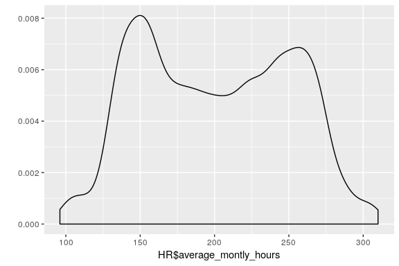

```r
#qplot(HR$average_montly_hours,geom="histogram", binwidth=500)

#try 1 & 1000 & 500 & 50

qplot(HR$average_montly_hours,
      geom="density")
```

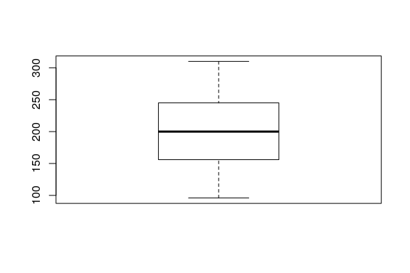

```r
boxplot(HR$average_montly_hours)
```

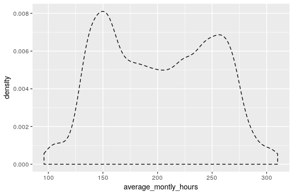

```r
ggplot(HR, aes(x = average_montly_hours)) + geom_density(alpha = .5,linetype="dashed")+ scale_fill_brewer(palette="Dark2")
```

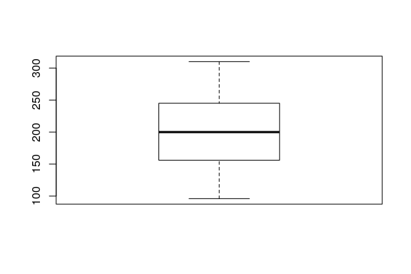

```r
boxplot(HR$average_montly_hours)
```

```r
summary(HR$average_montly_hours)
```

```
##    Min. 1st Qu.  Median    Mean 3rd Qu.    Max.
##    96.0   156.0   200.0   201.1   245.0   310.0
```

```r
#boxplot(average_montly_hours~sales,data=HR)
```

```r
#change the name of variable sales

names(HR)[names(HR) == 'sales'] <- 'department'
HR= HR %>% mutate(left = factor(left, labels = c("Remain", "Left")))

#change 0 & 1 to No and yes
HR= HR %>% mutate(Work_accident = factor(Work_accident, labels = c("accident_no", "accident_yes")))

#change 0 & 1 to No and yes

HR= HR %>% mutate(promotion_last_5years = factor(promotion_last_5years, labels = c("promotion_no", "promotion_yes")))
```

```r
summary(HR)
```

```
##  satisfaction_level last_evaluation  number_project  average_montly_hours
##  Min.   :0.0900     Min.   :0.3600   Min.   :2.000   Min.   : 96.0
##  1st Qu.:0.4400     1st Qu.:0.5600   1st Qu.:3.000   1st Qu.:156.0
##  Median :0.6400     Median :0.7200   Median :4.000   Median :200.0
##  Mean   :0.6128     Mean   :0.7161   Mean   :3.803   Mean   :201.1
##  3rd Qu.:0.8200     3rd Qu.:0.8700   3rd Qu.:5.000   3rd Qu.:245.0
##  Max.   :1.0000     Max.   :1.0000   Max.   :7.000   Max.   :310.0
##
##  time_spend_company      Work_accident       left
##  Min.   : 2.000     accident_no :12830   Remain:11428
##  1st Qu.: 3.000     accident_yes: 2169   Left  : 3571
##  Median : 3.000
##  Mean   : 3.498
##  3rd Qu.: 4.000
##  Max.   :10.000
##
##    promotion_last_5years       department      salary
##  promotion_no :14680     sales      :4140   high  :1237
##  promotion_yes:  319     technical  :2720   low   :7316
##                          support    :2229   medium:6446
##                          IT         :1227
##                          product_mng: 902
##                          marketing  : 858
##                          (Other)    :2923
```

## Exploratory Data Analysis

The aim of this section is mainly to investigate the relations between the predictor variables and the response variable.

**How many people leave from each department?**

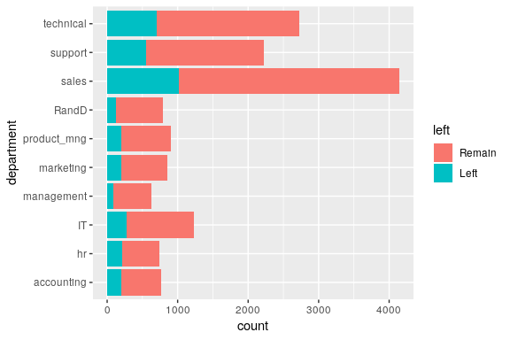

```r
department_left= HR %>% group_by(department,left) %>% summarise(count = n()) %>% mutate( freq= count/sum(count))

View(department_left)

c = ggplot(department_left, aes(x= department,y = count, fill=left)) + geom_bar( stat="identity")+ coord_flip()

c
```

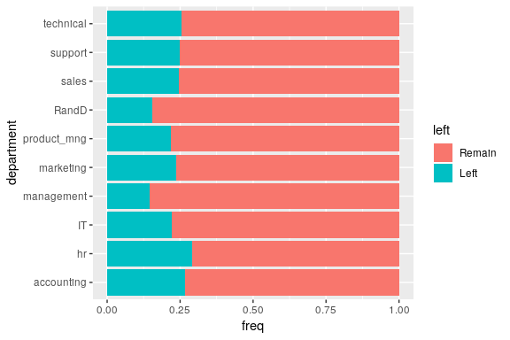

```r
# big percentage of the employees are actually working in sales. In this graph it hard to see exaclt the percentage of attrition within each group. Let's do some standridization.
ggplot(department_left, aes(x= department,y = freq, fill=left)) + geom_bar(aes(position= "fill" ), stat="identity")+ coord_flip()
```

**The correlation between salary level and leaving the company**

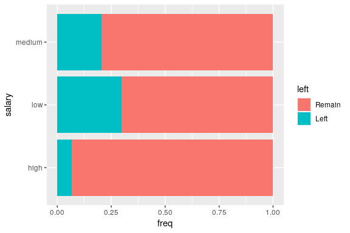

```r
salary_left =HR %>% group_by(salary,left) %>%  summarise(count = n()) %>% mutate( freq= count/sum(count))


ggplot(salary_left, aes(x= salary,y = freq, fill=left)) + geom_bar(aes(position= "fill" ), stat="identity")+ coord_flip()
```

**The distribution of salary levels across departments**

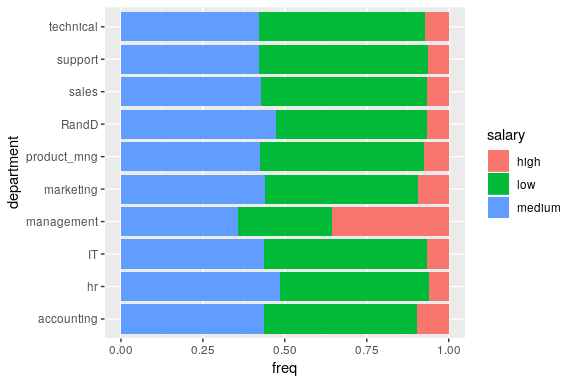

```r
salary_department = HR %>%  group_by(department,salary) %>%
 summarise(count = n()) %>%   mutate( freq= count/sum(count))

ggplot(salary_department, aes(x= department,y = freq, fill = salary)) + geom_bar(  stat="identity")+ coord_flip()
```

**The relation beteween department, salary and leaving**

```r
salary_department = HR %>%  group_by(department,salary,left) %>%
 summarise(count = n()) %>%   mutate( freq= count/sum(count))

head(salary_department)
```

```
## # A tibble: 6 x 5
## # Groups:   department, salary [3]
##   department salary left   count   freq
##   <fct>      <fct>  <fct>  <int>  <dbl>
## 1 accounting high   Remain    69 0.932
## 2 accounting high   Left       5 0.0676
## 3 accounting low    Remain   259 0.723
## 4 accounting low    Left      99 0.277
## 5 accounting medium Remain   235 0.701
## 6 accounting medium Left     100 0.299
```

```r
salary_department_left_only = subset(salary_department,salary_department$left=="Left")

head(salary_department_left_only)
```

```
## # A tibble: 6 x 5
## # Groups:   department, salary [6]
##   department salary left  count   freq
##   <fct>      <fct>  <fct> <int>  <dbl>
## 1 accounting high   Left      5 0.0676
## 2 accounting low    Left     99 0.277
## 3 accounting medium Left    100 0.299
## 4 hr         high   Left      6 0.133
## 5 hr         low    Left     92 0.275
## 6 hr         medium Left    117 0.326
```

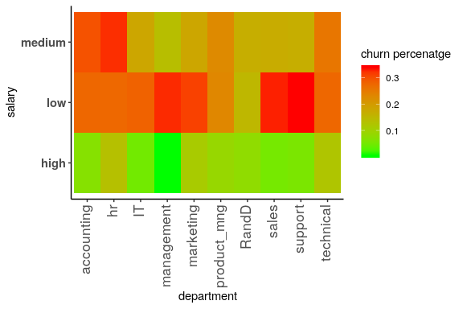

```r
ggplot(salary_department_left_only, aes(x= department,y = salary, fill = freq)) + geom_tile()+ scale_fill_gradient(name= "churn percenatge",low = "green", high = "red")+theme_classic()+ theme(axis.text.x = element_text(angle = 90,vjust=.3,hjust=1,size =13))+theme(axis.text.y = element_text(face = "bold",size =11))
```

**The relation between promotion and leaving**

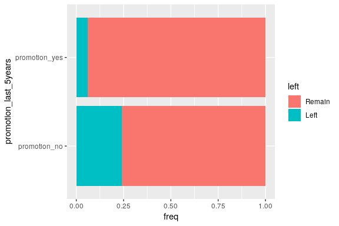

```r
promotion = HR %>% group_by(promotion_last_5years,left) %>% summarise(count = n()) %>% mutate( freq= count/sum(count))



ggplot(promotion, aes(x=promotion_last_5years ,y = freq, fill=left)) + geom_bar(aes(position= "fill" ), stat="identity")+ coord_flip()
```

**The relation beteween accident and leaving**

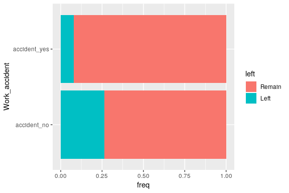

```r
accident = HR %>% group_by(Work_accident,left) %>%summarise(count = n()) %>% mutate( freq= count/sum(count))




ggplot(accident, aes(x=Work_accident ,y = freq, fill=left)) + geom_bar(aes(position= "fill" ), stat="identity")+ coord_flip()
```

**The relation beteween average monthly hours and leaving**

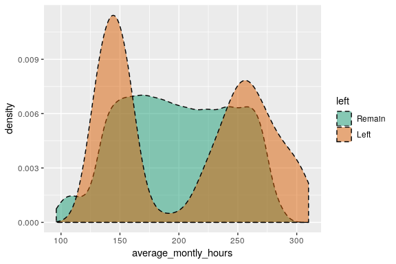

```r
ggplot(HR, aes(x = average_montly_hours, fill= left)) + geom_density(alpha = .5,linetype="dashed")+ scale_fill_brewer(palette="Dark2")
```

```r
HR$average_montly_hours<-cut(HR$average_montly_hours, c(0,176,216,350))
```

**The relation beteween department satisfaction level and leaving**

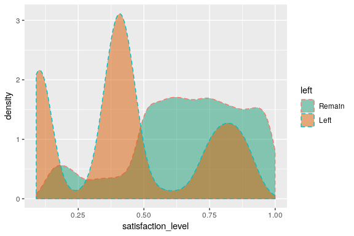

```r
ggplot(HR, aes(x = satisfaction_level, color = left, fill= left)) + geom_density(alpha = .5,linetype="dashed")+ scale_fill_brewer(palette="Dark2")
```

```r
##It is expected that people who rate their staisfaction as below .5 are likely to leave. However, big percentage of employees who thei level of satisfaction are more than .75 leave.
HR$satisfaction_level <-cut(HR$satisfaction_leve, c(0,.25,.5,.68,.88,1))
```

**The relation beteween number of projects and leaving**

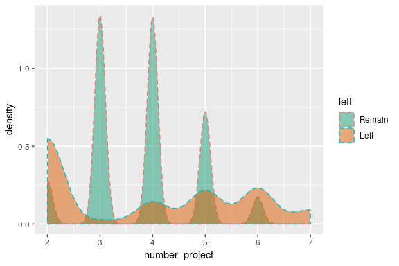

```r
ggplot(HR, aes(x = number_project, color = left, fill= left)) + geom_density(alpha = .5,linetype="dashed")+ scale_fill_brewer(palette="Dark2")
```

**The relation beteween last evaluation and leaving**

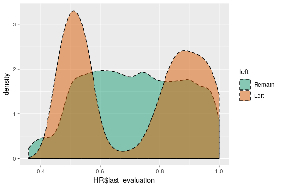

```r
ggplot(HR, aes(x = HR$last_evaluation, fill= left)) + geom_density(alpha = .5,linetype="dashed")+ scale_fill_brewer(palette="Dark2")
```

```r
##converting last evaluation to factor
HR$last_evaluation <-cut(HR$last_evaluation, c(0,.6,.8,1))
```

**The relation beteween time spend at the company and leaving**

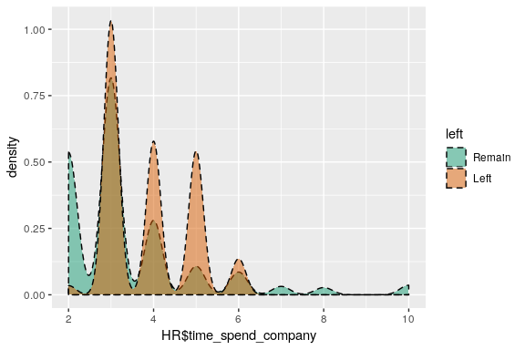

```r
ggplot(HR, aes(x = HR$time_spend_company, fill= left)) + geom_density(alpha = .5,linetype="dashed")+ scale_fill_brewer(palette="Dark2")
```

**Is their a relation between spending time at the company and the number of projects.**

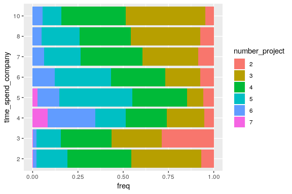

```r
HR$time_spend_company = as.factor(HR$time_spend_company)
HR$number_project = as.factor(HR$number_project)


time_project = HR %>% group_by(time_spend_company,number_project) %>% summarise(count = n()) %>% mutate( freq= count/sum(count))

ggplot(time_project, aes(x= time_spend_company,y = freq, fill = number_project)) + geom_bar(  stat="identity")+ coord_flip()
```

## Modelling

```r
#splitting the data for cross validation
set.seed(88)
split = sample.split(HR$left, SplitRatio = 0.75)
HRTrain = subset(HR, split == TRUE)
HRTest = subset(HR, split == FALSE)
```

### Building a Logitics Regression model. $Y = X\beta + \epsilon$

```r
#building a logistic model
model = glm(left ~ satisfaction_level + time_spend_company + last_evaluation + average_montly_hours + salary , data=HRTrain, family=binomial)
```

```r
#checking the odds
exp(coef(model))
```

```
##                   (Intercept)  satisfaction_level(0.25,0.5]
##                0.013580818618                2.671806318823
##  satisfaction_level(0.5,0.68] satisfaction_level(0.68,0.88]
##                0.039952527342                0.222894465936
##    satisfaction_level(0.88,1]           time_spend_company3
##                0.102953095552               13.847828203976
##           time_spend_company4           time_spend_company5
##               24.618647781564               79.723169475536
##           time_spend_company6           time_spend_company7
##               25.040235102220                0.000001790367
##           time_spend_company8          time_spend_company10
##                0.000001665019                0.000002799349
##      last_evaluation(0.6,0.8]        last_evaluation(0.8,1]
##                0.168299485993                1.329257669399
## average_montly_hours(176,216] average_montly_hours(216,350]
##                0.070588717316                1.771389217380
##                     salarylow                  salarymedium
##                4.984781191930                3.070236164724
```

```r
predictTrain = predict(model, type="response")
```

```r
table(HRTrain$left, predictTrain > 0.5)
```

```
##
##          FALSE TRUE
##   Remain  7903  668
##   Left     539 2139
```

```r
accuracy_train = (7903 + 2139) / 11249
accuracy_train
```

```
## [1] 0.8927016
```

```r
#performance on test data
predictTest = predict(model, newdata = HRTest, type="response")


table(HRTest$left, predictTest > 0.5)
```

```
##
##          FALSE TRUE
##   Remain  2654  203
##   Left     153  740
```

```r
accuracy_test = (740+2654)/3750
accuracy_test
```

```
## [1] 0.9050667
```

### Building a Desicion Tree model.

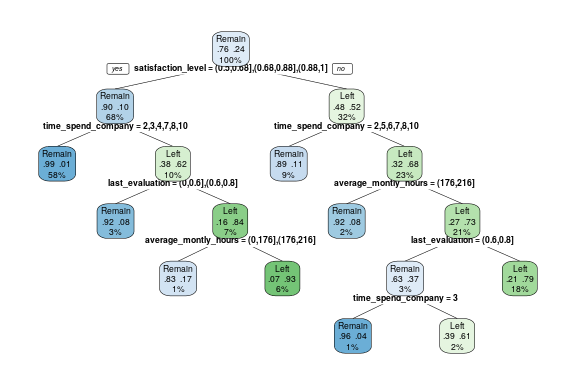

```r
set.seed(88)
tree <- rpart(left ~ satisfaction_level + time_spend_company +last_evaluation + average_montly_hours + salary ,  method= "class",data = HRTrain)






rpart.plot(tree, type = 2, extra = 104, tweak = 0.9, fallen.leaves = F,cex=.6)
```

```r
predict = predict(tree, newdata = HRTest , type = "class")
```

```r
table(HRTest$left,predict )
```

```
##         predict
##          Remain Left
##   Remain   2683  174
##   Left       92  801
```

```r
accuracy_tree_test = (801+2683) / 3750
accuracy_tree_test
```

```
## [1] 0.9290667
```

```r
#Variable importance is computed based on the corresponding reduction of predictive accuracy when the predictor of interest is removed
Tree_importance = varImp(tree)
Tree_importance
```

```
##                        Overall
## average_montly_hours 1156.2346
## last_evaluation      1185.2723
## salary                253.1619
## satisfaction_level   1126.4798
## time_spend_company   1660.0907
```

## Prescriptive Analytics

Suppose we have a limited budget for the retention plans.

1- Which employees should be targeted.

2- Build a measure for ranking employees according to their importance for your organization.

## Notes

1- Try to build your models with different combination of variables.

2- Determine the best combination of variables that gives you high accuracy on the test data.

3- Do you think accuracy is the best measure for your confusion matrix?

For more info about R [^1]

Contact Info[^2]

[^1]: http://www.cookbook-r.com/.
[^2]: sherif.rabie@appspatrols.com